# Veri Görselleştirme – Hafta 2

Dr. Öğr. Üyesi Zeynep ATLI

2026

# 1 Mapping Data to Aesthetics

Bu uygulamada, veri setindeki değişkenlerin grafik üzerindeki **görsel özelliklere (aesthetics)** nasıl eşlendiğini inceleyeceğiz. Temel amacımız yalnızca `ggplot2` kodlarını çalıştırmak değil, bir grafiğin hangi bileşenlerden oluştuğunu anlamaktır.

Bir veri tablosundaki değerleri doğrudan görmeyiz. Veriyi; **konum, renk, boyut, şekil, saydamlık ve çizgi tipi** gibi görsel özellikler aracılığıyla görünür hale getiririz.

Bu haftanın temel sorusu şudur:

> Bir değişkeni grafikte göstermek istediğimizde, onu hangi görsel özellikle temsil etmeliyiz?

# 2 1. Gerekli paket

Bu uygulamada `ggplot2` paketini kullanacağız.

```r
# Paketi daha önce yüklemediyseniz bir kez çalıştırın:
# install.packages("ggplot2")

library(ggplot2)
```

# 3 2. Aesthetics (Görsel Özellikler) Nedir?

`ggplot2` terminolojisinde **aesthetic**, veriyi grafik üzerinde temsil etmek için kullanılan görsel özellikleri ifade eder. Buradaki “estetik” sözcüğü grafiğin güzel görünmesi anlamına gelmez.

Yaygın görsel özelliklerden bazıları şunlardır:

- `x`: yatay konum
- `y`: dikey konum
- `color`: renk
- `fill`: dolgu rengi
- `size`: boyut
- `shape`: şekil
- `alpha`: saydamlık
- `linetype`: çizgi tipi

Her görsel özellik her veri türü için aynı derecede uygun değildir. Örneğin sürekli bir değişkeni çok sayıda farklı şekille temsil etmek çoğu durumda iyi bir tercih değildir.

# 4 3. Kullanacağımız Veri: mtcars

R ile birlikte gelen `mtcars` veri setini kullanacağız. Veri seti farklı otomobillere ilişkin teknik özellikleri içermektedir.

```r
df <- mtcars

head(df)
```

```
##                    mpg cyl disp  hp drat    wt  qsec vs am gear carb
## Mazda RX4         21.0   6  160 110 3.90 2.620 16.46  0  1    4    4
## Mazda RX4 Wag     21.0   6  160 110 3.90 2.875 17.02  0  1    4    4
## Datsun 710        22.8   4  108  93 3.85 2.320 18.61  1  1    4    1
## Hornet 4 Drive    21.4   6  258 110 3.08 3.215 19.44  1  0    3    1
## Hornet Sportabout 18.7   8  360 175 3.15 3.440 17.02  0  0    3    2
## Valiant           18.1   6  225 105 2.76 3.460 20.22  1  0    3    1
```

Veriyi görselleştirmeden önce yapısını incelemek önemlidir.

```r
str(df)
```

```
## 'data.frame':    32 obs. of  11 variables:
##  $ mpg : num  21 21 22.8 21.4 18.7 18.1 14.3 24.4 22.8 19.2 ...
##  $ cyl : num  6 6 4 6 8 6 8 4 4 6 ...
##  $ disp: num  160 160 108 258 360 ...
##  $ hp  : num  110 110 93 110 175 105 245 62 95 123 ...
##  $ drat: num  3.9 3.9 3.85 3.08 3.15 2.76 3.21 3.69 3.92 3.92 ...
##  $ wt  : num  2.62 2.88 2.32 3.21 3.44 ...
##  $ qsec: num  16.5 17 18.6 19.4 17 ...
##  $ vs  : num  0 0 1 1 0 1 0 1 1 1 ...
##  $ am  : num  1 1 1 0 0 0 0 0 0 0 ...
##  $ gear: num  4 4 4 3 3 3 3 4 4 4 ...
##  $ carb: num  4 4 1 1 2 1 4 2 2 4 ...
```

```r
dim(df)
```

```
## [1] 32 11
```

```r
names(df)
```

```
##  [1] "mpg"  "cyl"  "disp" "hp"   "drat" "wt"   "qsec" "vs"   "am"   "gear"
## [11] "carb"
```

Bu uygulamada özellikle şu değişkenleri kullanacağız:

- `mpg`: yakıt verimliliği (miles per gallon)
- `disp`: motor hacmi
- `hp`: motor gücü
- `wt`: araç ağırlığı
- `cyl`: silindir sayısı

**Not:** `cyl` R içinde sayısal görünmesine rağmen 4, 6 ve 8 silindirli araç gruplarını temsil eder. Bu nedenle bazı grafiklerde `factor(cyl)` biçiminde kategorik olarak ele alacağız.

# 5 4. İlk ggplot Grafiği

Önce motor hacmi (`disp`) ile yakıt verimliliği (`mpg`) arasındaki ilişkiyi çizelim.

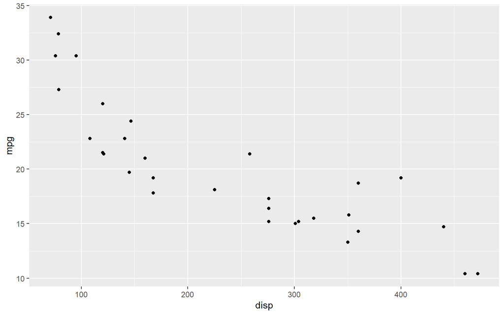

```r
ggplot(data = df,
       aes(x = disp, y = mpg)) +
  geom_point()
```

Bu kod üç temel parçadan oluşur:

1. `data = df`: Hangi veri setinin kullanılacağını belirtir.
2. `aes(x = disp, y = mpg)`: Değişkenleri görsel özelliklere eşler.
3. `geom_point()`: Her gözlemi bir nokta olarak gösterir.

Grafikteki **her nokta bir otomobili** temsil eder. Motor hacmi arttıkça `mpg` değerinin genel olarak azaldığı görülmektedir. Ancak bu grafik tek başına nedensellik göstermez.

# 6 5. Mapping Nedir?

**Mapping**, veri setindeki bir değişkenin bir görsel özelliğe bağlanmasıdır.

Örneğin:

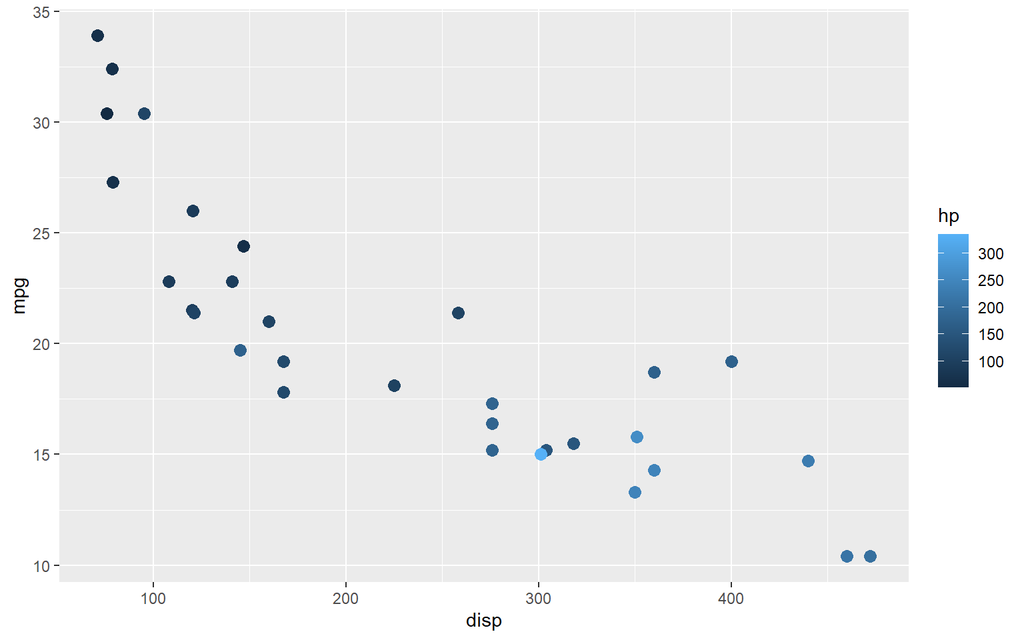

```r
ggplot(df,
       aes(x = disp,
           y = mpg,
           color = hp)) +
  geom_point(size = 3)
```

Burada `hp` değişkeni `color` özelliğine eşlenmiştir. Dolayısıyla noktaların rengi otomobillerin motor gücüne göre değişmektedir.

Başka bir ifadeyle:

**Veri değişkeni → görsel özellik**

şeklinde bir ilişki kurulmuştur.

# 7 6. Mapping ve Setting Arasındaki Fark

Bu ayrım `ggplot2` öğrenirken en önemli konulardan biridir.

## 7.1 6.1. Setting: Sabit bir görünüm vermek

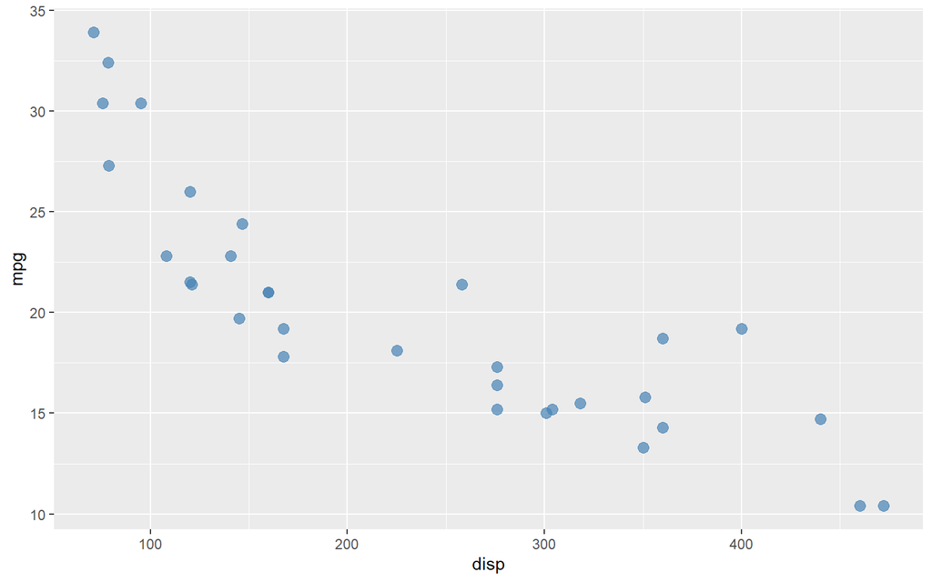

```r
ggplot(df,
       aes(x = disp, y = mpg)) +
  geom_point(
    color = "steelblue",
    size = 3,
    alpha = 0.7
  )
```

Burada bütün noktalar aynı renkte ve aynı büyüklüktedir. `color`, `size` ve `alpha` herhangi bir değişkene bağlanmamıştır.

Bu nedenle bunlar **mapping değil, sabit görsel ayarlardır (setting)**.

## 7.2 6.2. Mapping: Görsel özelliği veriye bağlamak

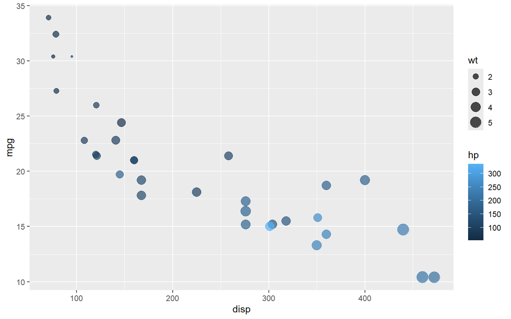

```r
ggplot(df,
       aes(x = disp,
           y = mpg,
           color = hp,
           size = wt)) +
  geom_point(alpha = 0.7)
```

Bu kez:

- renk (`color`) → motor gücüne (`hp`),
- boyut (`size`) → araç ağırlığına (`wt`)

bağlanmıştır.

Dolayısıyla renk ve boyut artık **veri taşımaktadır**.

> Temel kural: Bir değişkeni görsel özelliğe bağlamak istiyorsanız genellikle `aes()` içine yazarsınız. Sabit bir görünüm vermek istiyorsanız özelliği `aes()` dışında tanımlarsınız.

# 8 7. Renk (color) ile Kategorik Değişken Gösterme

Silindir sayısını farklı renklerle gösterelim.

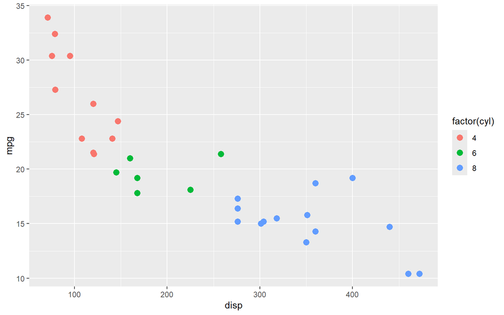

```r
ggplot(df,
       aes(x = disp,
           y = mpg,
           color = factor(cyl))) +
  geom_point(size = 3)
```

`factor(cyl)` kullanmamızın nedeni silindir sayısını burada sürekli bir ölçümden çok **araç grupları** olarak ele almamızdır.

Grafiğin açıklamasını daha anlaşılır hale getirebiliriz:

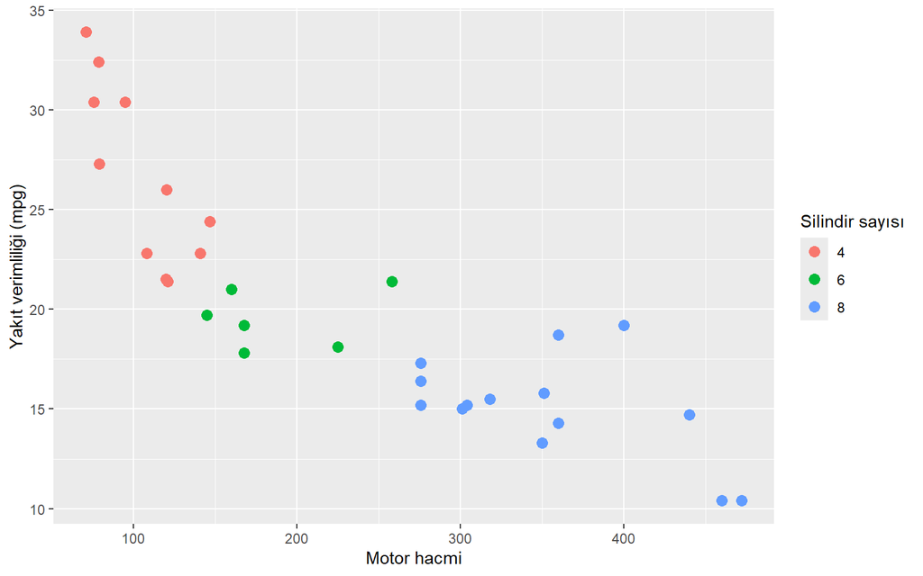

```r
ggplot(df,
       aes(x = disp,
           y = mpg,
           color = factor(cyl))) +
  geom_point(size = 3) +
  labs(
    x = "Motor hacmi",
    y = "Yakıt verimliliği (mpg)",
    color = "Silindir sayısı"
  )
```

# 9 8. Shape ile Grupları Ayırma

Kategorik değişkenler şekil kullanılarak da temsil edilebilir.

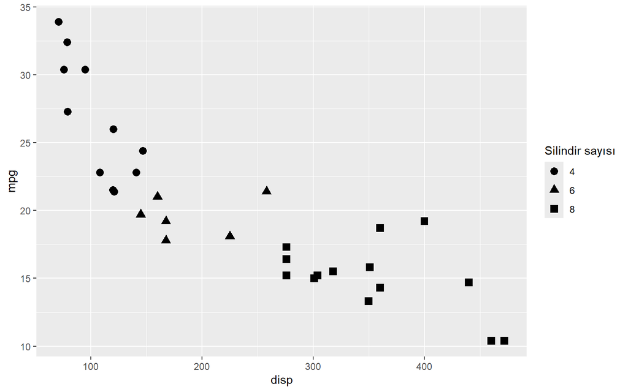

```r
ggplot(df,
       aes(x = disp,
           y = mpg,
           shape = factor(cyl))) +
  geom_point(size = 3) +
  labs(shape = "Silindir sayısı")
```

Şekil, az sayıda kategori olduğunda kullanışlıdır. Çok fazla kategori olduğunda şekilleri birbirinden ayırmak zorlaşır.

# 10 9. Birden Fazla Aesthetic Kullanmak

Bir grafikte birden fazla değişkeni aynı anda gösterebiliriz.

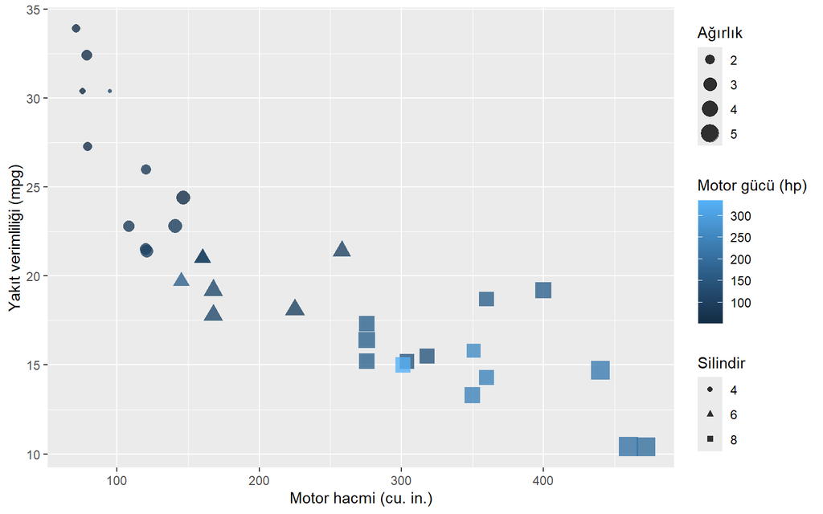

```r
ggplot(df,
       aes(x = disp,
           y = mpg,
           color = hp,
           size = wt,
           shape = factor(cyl))) +
  geom_point(alpha = 0.8) +
  labs(
    x = "Motor hacmi (cu. in.)",
    y = "Yakıt verimliliği (mpg)",
    color = "Motor gücü (hp)",
    size = "Ağırlık",
    shape = "Silindir"
  )
```

Bu grafikte aynı gözlem hakkında birden fazla bilgi gösterilmektedir:

- x konumu → `disp`
- y konumu → `mpg`
- renk → `hp`
- boyut → `wt`
- şekil → `cyl`

Ancak daha fazla değişken gösterebilmek her zaman daha iyi bir grafik anlamına gelmez. Görsel karmaşıklık arttıkça grafiğin okunabilirliği azalabilir.

# 11 10. Alpha: Saydamlık

`alpha`, noktaların saydamlığını kontrol eder.

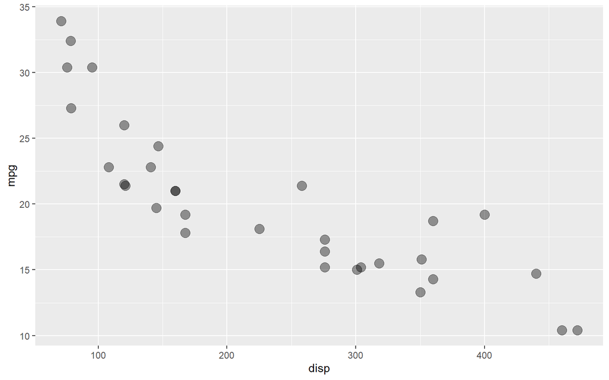

```r
ggplot(df,
       aes(x = disp, y = mpg)) +
  geom_point(size = 4, alpha = 0.4)
```

`alpha` değeri 0’a yaklaştıkça nesne daha saydam, 1’e yaklaştıkça daha opak görünür. Özellikle çok sayıda gözlemin üst üste geldiği grafiklerde yararlıdır.

# 12 11. Geometry: Veriyi Nasıl Göstereceğiz?

Mapping bize **hangi değişkenin hangi görsel özelliğe bağlanacağını** söyler. Geometry ise bu bilgiyi **hangi geometrik biçimle göstereceğimizi** belirler.

Örneğin:

- `geom_point()` → nokta
- `geom_line()` → çizgi
- `geom_bar()` → sütun
- `geom_histogram()` → histogram
- `geom_boxplot()` → kutu grafiği
- `geom_density()` → yoğunluk eğrisi

Aynı veri farklı geometrilerle farklı sorulara cevap verebilir.

## 12.1 Histogram örneği

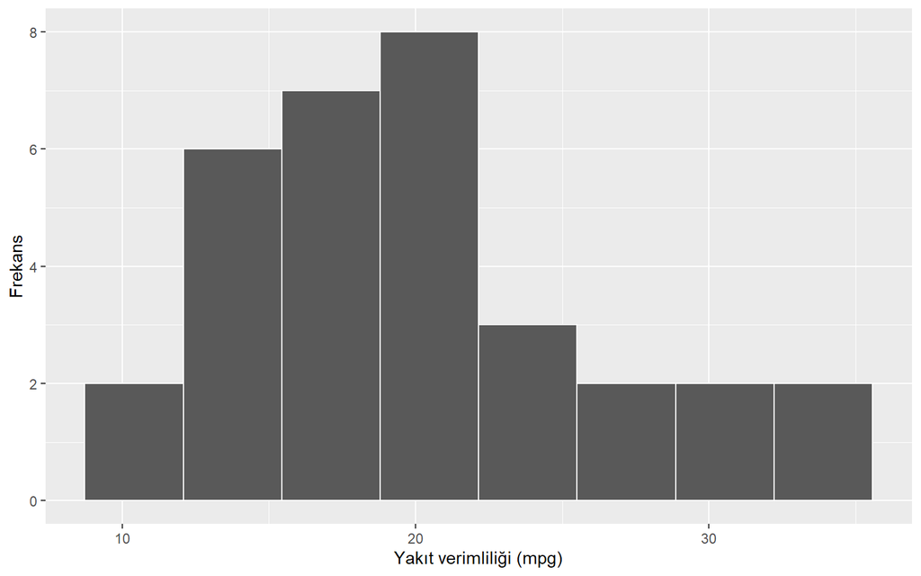

```r
ggplot(df, aes(x = mpg)) +
  geom_histogram(bins = 8, color = "white") +
  labs(x = "Yakıt verimliliği (mpg)", y = "Frekans")
```

## 12.2 Kutu grafiği örneği

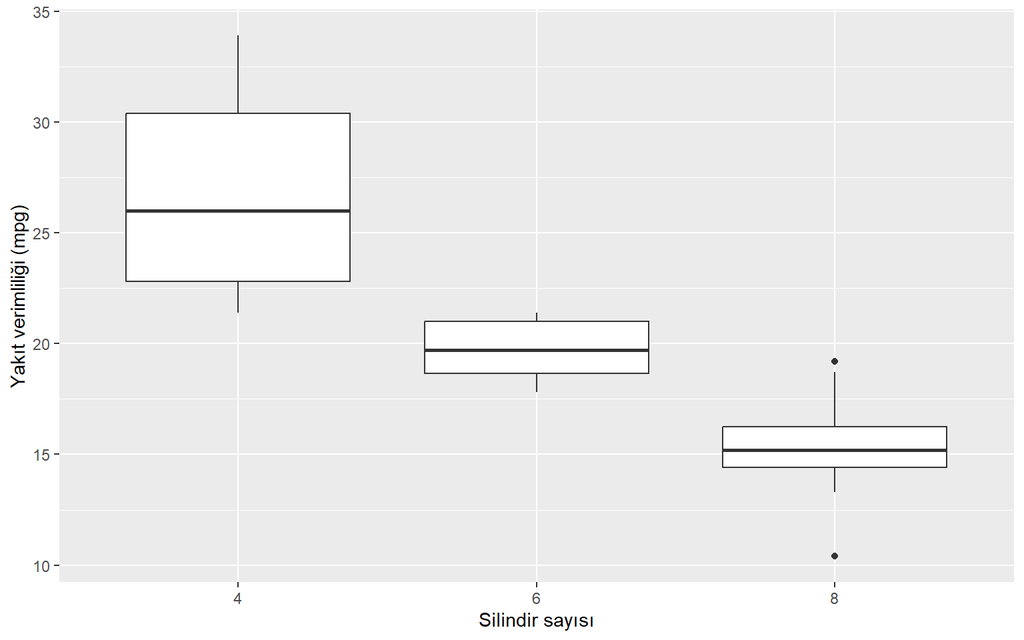

```r
ggplot(df,
       aes(x = factor(cyl),
           y = mpg)) +
  geom_boxplot() +
  labs(x = "Silindir sayısı", y = "Yakıt verimliliği (mpg)")
```

# 13 12. Grammar of Graphics

`ggplot2`, **Grammar of Graphics** yaklaşımını temel alır. Bir grafik tek bir nesne olarak değil, birbiriyle ilişkili bileşenlerin birleşimi olarak düşünülebilir.

Basitleştirilmiş biçimde:

**Data → Aesthetics → Geometry → Scales → Facets → Coordinates → Theme**

Örneğin:

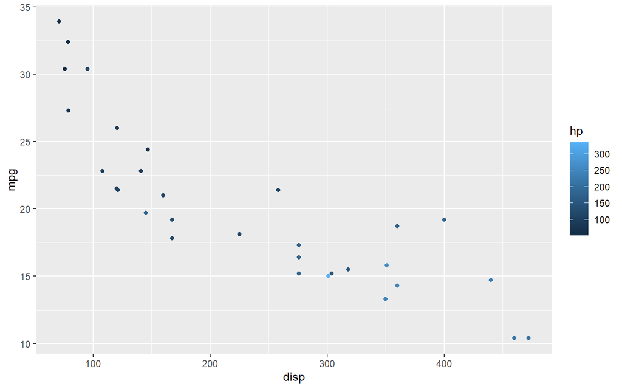

```r
ggplot(data = df,
       aes(x = disp,
           y = mpg,
           color = hp)) +
  geom_point()
```

Burada:

- **Data:** `df`
- **Aesthetic mapping:** `disp`, `mpg`, `hp`
- **Geometry:** `geom_point()`

bulunmaktadır.

Bu yaklaşımın önemli avantajı, grafiği ezberlenecek tek bir komut yerine **katmanlardan oluşan bir yapı** olarak düşünmemizi sağlamasıdır.

# 14 13. Scale Nedir?

Mapping ve scale aynı şey değildir.

**Mapping**, hangi değişkenin hangi görsel özelliğe bağlanacağını belirler.

**Scale**, veri değerlerinin bu görsel özellik üzerinde **nasıl temsil edileceğini** belirler.

Örneğin:

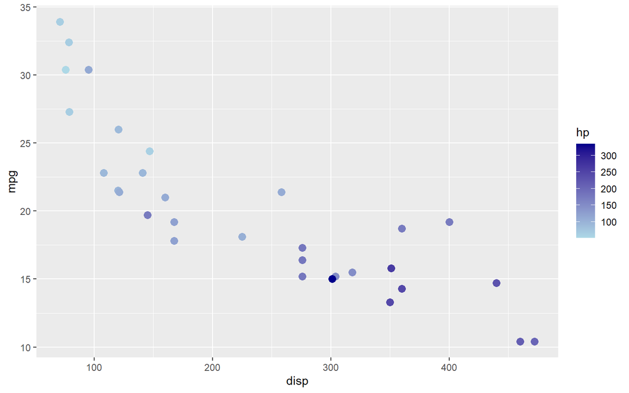

```r
ggplot(df,
       aes(x = disp,
           y = mpg,
           color = hp)) +
  geom_point(size = 3) +
  scale_color_gradient(
    low = "lightblue",
    high = "darkblue"
  )
```

Burada:

```r
color = hp
```

bir **mapping** işlemidir.

```r
scale_color_gradient(...)
```

ise bu değerlerin hangi renklerle gösterileceğini düzenleyen **scale** işlemidir.

Kısaca:

> Mapping = **Neyi neye bağlıyorum?**  
> Scale = **Bu bağlantıyı nasıl gösteriyorum?**

# 15 14. Başlık ve Eksen İsimleri: labs()

Grafiklerin okuyucu tarafından anlaşılması için açıklayıcı başlıklar ve eksen isimleri kullanılmalıdır.

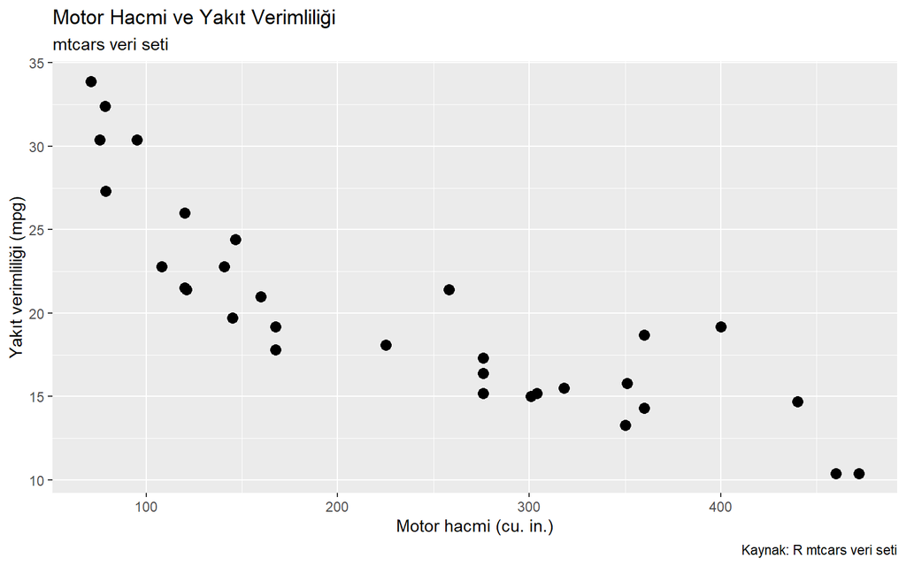

```r
ggplot(df,
       aes(x = disp, y = mpg)) +
  geom_point(size = 3) +
  labs(
    title = "Motor Hacmi ve Yakıt Verimliliği",
    subtitle = "mtcars veri seti",
    x = "Motor hacmi (cu. in.)",
    y = "Yakıt verimliliği (mpg)",
    caption = "Kaynak: R mtcars veri seti"
  )
```

# 16 15. Grafik İçine Metin Eklemek

Bir grafikte önemli bir bölgeyi veya gözlemi açıklamak için `annotate()` kullanılabilir.

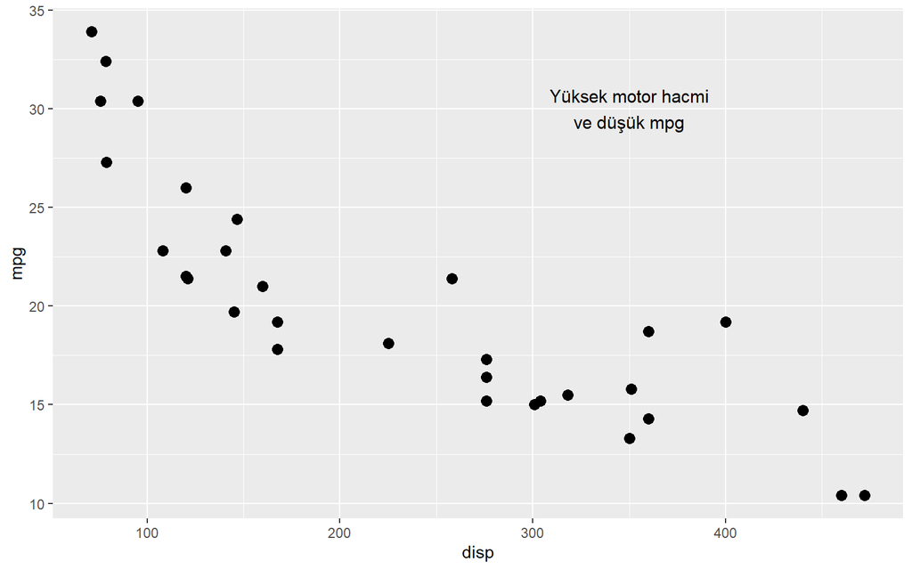

```r
ggplot(df,
       aes(x = disp, y = mpg)) +
  geom_point(size = 3) +
  annotate(
    "text",
    x = 350,
    y = 30,
    label = "Yüksek motor hacmi\nve düşük mpg",
    size = 4
  )
```

# 17 16. Grafik Üzerinde Ok Kullanmak

Bir noktaya veya bölgeye dikkat çekmek için `annotate()` ile segment ve ok ekleyebiliriz.

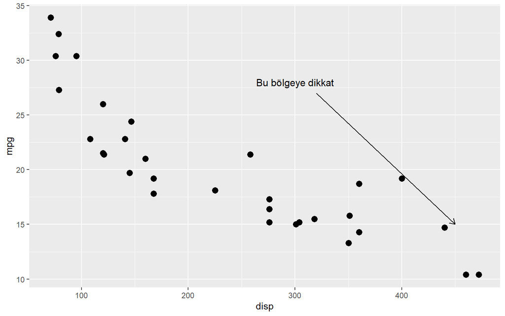

```r
ggplot(df,
       aes(x = disp, y = mpg)) +
  geom_point(size = 3) +
  annotate(
    "segment",
    x = 320, xend = 450,
    y = 27, yend = 15,
    arrow = arrow(length = unit(0.25, "cm"))
  ) +
  annotate(
    "text",
    x = 300,
    y = 28,
    label = "Bu bölgeye dikkat",
    size = 4
  )
```

Ok kullanmak mümkün olsa da her grafikte gerekli değildir. Vurgu, yalnızca okuyucunun dikkatini gerçekten yönlendirmek istediğimiz durumlarda kullanılmalıdır.

# 18 17. Theme: Grafiğin Genel Görünümü

Tema, grafikteki veri eşlemesini değiştirmez. Arka plan, grid çizgileri ve genel görsel düzen gibi öğeleri kontrol eder.

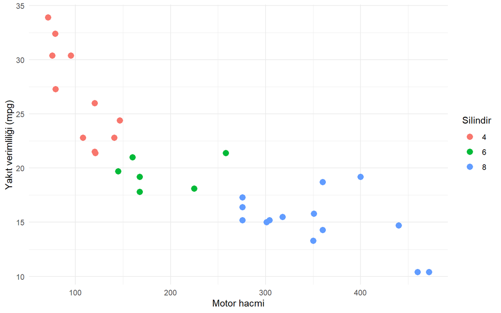

```r
ggplot(df,
       aes(x = disp,
           y = mpg,
           color = factor(cyl))) +
  geom_point(size = 3) +
  labs(
    x = "Motor hacmi",
    y = "Yakıt verimliliği (mpg)",
    color = "Silindir"
  ) +
  theme_minimal()
```

Başka bir örnek:

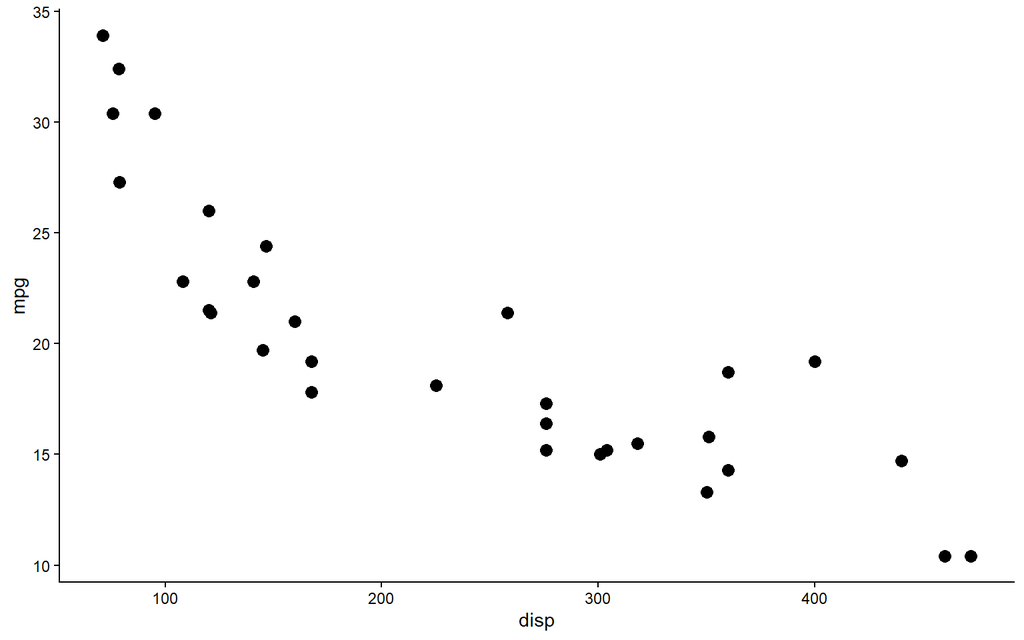

```r
ggplot(df,
       aes(x = disp, y = mpg)) +
  geom_point(size = 3) +
  theme_classic()
```

# 19 18. Tam Bir ggplot Örneği

Şimdi öğrendiğimiz bazı bileşenleri tek grafikte birleştirelim.

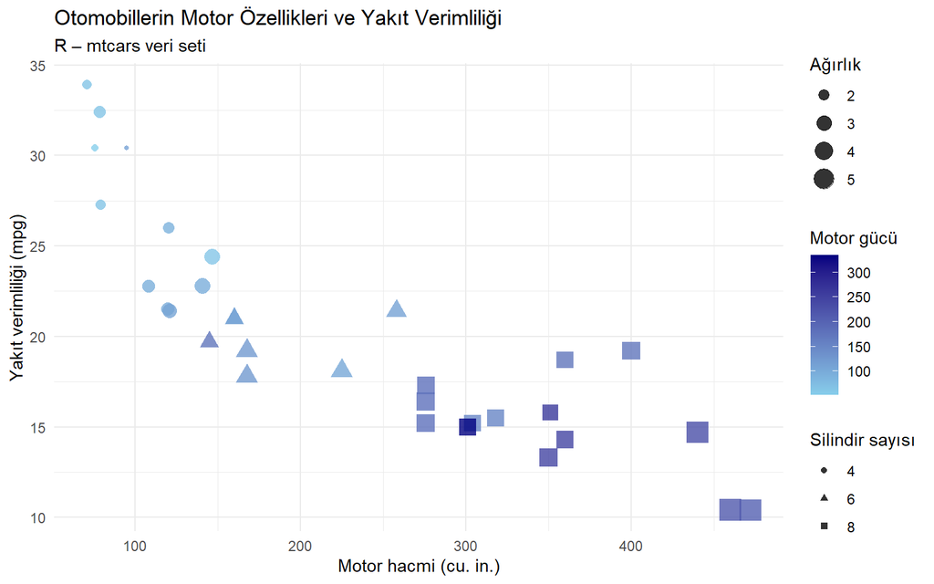

```r
ggplot(df,
       aes(x = disp,
           y = mpg,
           color = hp,
           size = wt,
           shape = factor(cyl))) +
  geom_point(alpha = 0.8) +
  scale_color_gradient(
    low = "skyblue",
    high = "navy"
  ) +
  labs(
    title = "Otomobillerin Motor Özellikleri ve Yakıt Verimliliği",
    subtitle = "R – mtcars veri seti",
    x = "Motor hacmi (cu. in.)",
    y = "Yakıt verimliliği (mpg)",
    color = "Motor gücü",
    size = "Ağırlık",
    shape = "Silindir sayısı"
  ) +
  theme_minimal()
```

Bu kodu artık katmanlarına ayırabiliriz:

1. **Data:** `df`
2. **Mapping:** `disp`, `mpg`, `hp`, `wt`, `cyl`
3. **Geometry:** `geom_point()`
4. **Scale:** `scale_color_gradient()`
5. **Labels:** `labs()`
6. **Theme:** `theme_minimal()`

# 20 19. Uygulama Soruları

Aşağıdaki soruları kod yazarak tamamlayınız.

## 20.1 Soru 1

`wt` değişkenini x eksenine, `mpg` değişkenini y eksenine yerleştirerek bir saçılım grafiği oluşturunuz.

```r
# Kodunuzu buraya yazınız.
```

## 20.2 Soru 2

Birinci grafikteki noktaların rengini sabit olarak `steelblue` yapınız. Bu işlem mapping mi, setting mi?

```r
# Kodunuzu buraya yazınız.
```

## 20.3 Soru 3

`cyl` değişkenini renge eşleyiniz. Önce `color = cyl`, ardından `color = factor(cyl)` kullanarak iki grafiği karşılaştırınız.

```r
# Kodunuzu buraya yazınız.
```

## 20.4 Soru 4

`hp` değişkenini renge, `wt` değişkenini boyuta eşleyiniz.

```r
# Kodunuzu buraya yazınız.
```

## 20.5 Soru 5

Grafiğinize anlamlı bir başlık, x ve y ekseni isimleri ekleyiniz ve `theme_minimal()` kullanınız.

```r
# Kodunuzu buraya yazınız.
```

# 21 20. Kendinizi Kontrol Edin

Aşağıdaki soruları kod yazmadan cevaplamaya çalışınız:

1. `aes()` fonksiyonunun temel görevi nedir?
2. `geom_point(color = "red")` ile `aes(color = cyl)` arasındaki temel fark nedir?
3. `color = hp` ifadesinde renk veri taşır mı?
4. `size = 3` ifadesinde boyut veri taşır mı?
5. Mapping ile scale arasındaki fark nedir?
6. `geom_point()` Grammar of Graphics’in hangi bileşenine karşılık gelir?
7. `theme_minimal()` veriyi mi, grafiğin görünümünü mü değiştirir?

Hatırlatma

> **Mapping**, hangi değişkenin hangi görsel özelliğe bağlanacağını belirler.

> **Scale**, bu değerlerin grafik üzerinde nasıl temsil edileceğini belirler.